# investigate-a-dataset

#### Project: Investigate TMDb movie data

- Introduction
- Data Wrangling
- Exploratory Data Analysis
- Conclusions

## Introduction

TMDb data set has 10866 list of movies dated between 1960 through 2015. The questions that I plan on exploring this dataset are

- What kinds of properties are associated with movies that have high revenues?
- How does vote count affect revenue?
- Which genre has most number of movies?
- Which genres generate the highest revenue?

```python
import pandas as pd
import numpy as np
import seaborn as sn
import matplotlib.pyplot as plt
from matplotlib.ticker import FuncFormatter
%matplotlib inline
```

## Data Wrangling

### General Properties

```python
# Loading the data and viewing data

movies = pd.read_csv("tmdb-movies.csv")
movies.head(2)
```

|  | id | imdb_id | popularity | budget | revenue | original_title | cast | homepage | director | tagline | ... | overview | runtime | genres | production_companies | release_date | vote_count | vote_average | release_year | budget_adj | revenue_adj |
| --- | --- | --- | --- | --- | --- | --- | --- | --- | --- | --- | --- | --- | --- | --- | --- | --- | --- | --- | --- | --- | --- |
| 0 | 135397 | tt0369610 | 32.985763 | 150000000 | 1513528810 | Jurassic World | Chris Pratt\|Bryce Dallas Howard\|Irrfan Khan\|Vi... | http://www.jurassicworld.com/ | Colin Trevorrow | The park is open. | ... | Twenty-two years after the events of Jurassic ... | 124 | Action\|Adventure\|Science Fiction\|Thriller | Universal Studios\|Amblin Entertainment\|Legenda... | 6/9/15 | 5562 | 6.5 | 2015 | 1.379999e+08 | 1.392446e+09 |
| 1 | 76341 | tt1392190 | 28.419936 | 150000000 | 378436354 | Mad Max: Fury Road | Tom Hardy\|Charlize Theron\|Hugh Keays-Byrne\|Nic... | http://www.madmaxmovie.com/ | George Miller | What a Lovely Day. | ... | An apocalyptic story set in the furthest reach... | 120 | Action\|Adventure\|Science Fiction\|Thriller | Village Roadshow Pictures\|Kennedy Miller Produ... | 5/13/15 | 6185 | 7.1 | 2015 | 1.379999e+08 | 3.481613e+08 |

2 rows × 21 columns

```python
# viewing the summary of the data such as number of rows and columns, data types and many more.
movies.info()
```

```
<class 'pandas.core.frame.DataFrame'>
RangeIndex: 10866 entries, 0 to 10865
Data columns (total 21 columns):
 #   Column                Non-Null Count  Dtype
---  ------                --------------  -----
 0   id                    10866 non-null  int64
 1   imdb_id               10856 non-null  object
 2   popularity            10866 non-null  float64
 3   budget                10866 non-null  int64
 4   revenue               10866 non-null  int64
 5   original_title        10866 non-null  object
 6   cast                  10790 non-null  object
 7   homepage              2936 non-null   object
 8   director              10822 non-null  object
 9   tagline               8042 non-null   object
 10  keywords              9373 non-null   object
 11  overview              10862 non-null  object
 12  runtime               10866 non-null  int64
 13  genres                10843 non-null  object
 14  production_companies  9836 non-null   object
 15  release_date          10866 non-null  object
 16  vote_count            10866 non-null  int64
 17  vote_average          10866 non-null  float64
 18  release_year          10866 non-null  int64
 19  budget_adj            10866 non-null  float64
 20  revenue_adj           10866 non-null  float64
dtypes: float64(4), int64(6), object(11)
memory usage: 1.7+ MB
```

```python
# Summary statistics of the data.
movies.describe()
```

|  | id | popularity | budget | revenue | runtime | vote_count | vote_average | release_year | budget_adj | revenue_adj |
| --- | --- | --- | --- | --- | --- | --- | --- | --- | --- | --- |
| count | 10866.000000 | 10866.000000 | 1.086600e+04 | 1.086600e+04 | 10866.000000 | 10866.000000 | 10866.000000 | 10866.000000 | 1.086600e+04 | 1.086600e+04 |
| mean | 66064.177434 | 0.646441 | 1.462570e+07 | 3.982332e+07 | 102.070863 | 217.389748 | 5.974922 | 2001.322658 | 1.755104e+07 | 5.136436e+07 |
| std | 92130.136561 | 1.000185 | 3.091321e+07 | 1.170035e+08 | 31.381405 | 575.619058 | 0.935142 | 12.812941 | 3.430616e+07 | 1.446325e+08 |
| min | 5.000000 | 0.000065 | 0.000000e+00 | 0.000000e+00 | 0.000000 | 10.000000 | 1.500000 | 1960.000000 | 0.000000e+00 | 0.000000e+00 |
| 25% | 10596.250000 | 0.207583 | 0.000000e+00 | 0.000000e+00 | 90.000000 | 17.000000 | 5.400000 | 1995.000000 | 0.000000e+00 | 0.000000e+00 |
| 50% | 20669.000000 | 0.383856 | 0.000000e+00 | 0.000000e+00 | 99.000000 | 38.000000 | 6.000000 | 2006.000000 | 0.000000e+00 | 0.000000e+00 |
| 75% | 75610.000000 | 0.713817 | 1.500000e+07 | 2.400000e+07 | 111.000000 | 145.750000 | 6.600000 | 2011.000000 | 2.085325e+07 | 3.369710e+07 |
| max | 417859.000000 | 32.985763 | 4.250000e+08 | 2.781506e+09 | 900.000000 | 9767.000000 | 9.200000 | 2015.000000 | 4.250000e+08 | 2.827124e+09 |

### Drop Extraneous Columns

```python
# drop columns from movies dataset as the homepage and tagline and keywords have the maximum null values.
movies.drop(['id', 'imdb_id', 'homepage', 'tagline', 'keywords','overview'], axis=1, inplace=True)

# confirm changes
movies.head(2)
```

|  | popularity | budget | revenue | original_title | cast | director | runtime | genres | production_companies | release_date | vote_count | vote_average | release_year | budget_adj | revenue_adj |
| --- | --- | --- | --- | --- | --- | --- | --- | --- | --- | --- | --- | --- | --- | --- | --- |
| 0 | 32.985763 | 150000000 | 1513528810 | Jurassic World | Chris Pratt\|Bryce Dallas Howard\|Irrfan Khan\|Vi... | Colin Trevorrow | 124 | Action\|Adventure\|Science Fiction\|Thriller | Universal Studios\|Amblin Entertainment\|Legenda... | 6/9/15 | 5562 | 6.5 | 2015 | 1.379999e+08 | 1.392446e+09 |
| 1 | 28.419936 | 150000000 | 378436354 | Mad Max: Fury Road | Tom Hardy\|Charlize Theron\|Hugh Keays-Byrne\|Nic... | George Miller | 120 | Action\|Adventure\|Science Fiction\|Thriller | Village Roadshow Pictures\|Kennedy Miller Produ... | 5/13/15 | 6185 | 7.1 | 2015 | 1.379999e+08 | 3.481613e+08 |

### Dedupe

```python
# Check for duplicates.
sum(movies.duplicated())
```

```
1
```

```python
# Remove Duplicated rows
movies.drop_duplicates(inplace=True)
```

```python
# checking for duplicate values after dropping
sum(movies.duplicated())
```

```
0
```

### Check for Null values

```python
#Check for null values
movies.isnull().sum()
```

```
popularity                 0
budget                     0
revenue                    0
original_title             0
cast                      76
director                  44
runtime                    0
genres                    23
production_companies    1030
release_date               0
vote_count                 0
vote_average               0
release_year               0
budget_adj                 0
revenue_adj                0
dtype: int64
```

```python
# Drop rows with any null values
movies.dropna(axis=0, how='any', inplace=True)
```

```python
# Confirming the number of null values
movies.isnull().any().sum()
```

```
0
```

```python
movies.shape
```

```
(9772, 15)
```

```python
movies.query('budget == 0').shape[0]
```

```
4751
```

### Replacing zeros with mean

- From the summary statistics, I see that the budget and revenue columns have 0 value. I will replace zero with the mean values as there are large number of rows containing zeroes.

```python
# Checking for the number of 0's in all columns.
movies.isin([0]).sum()
```

```
popularity                 0
budget                  4751
revenue                 5022
original_title             0
cast                       0
director                   0
runtime                   13
genres                     0
production_companies       0
release_date               0
vote_count                 0
vote_average               0
release_year               0
budget_adj              4751
revenue_adj             5022
dtype: int64
```

```python
# Replacing 0's for the columns budget, revenue, budget_adj, revenue_adj

movies.budget = movies.budget.replace(0, movies.budget.mean())
movies.revenue = movies.revenue.replace(0, movies.revenue.mean())
movies.budget_adj = movies.budget_adj.replace(0, movies.budget_adj.mean())
movies.revenue_adj = movies.budget.replace(0, movies.revenue_adj.mean())
```

```python
movies.isin([0]).sum()
```

```
popularity               0
budget                   0
revenue                  0
original_title           0
cast                     0
director                 0
runtime                 13
genres                   0
production_companies     0
release_date             0
vote_count               0
vote_average             0
release_year             0
budget_adj               0
revenue_adj              0
dtype: int64
```

As runtime has only 13, 0 values, I am leaving them as it is.

### Convert the data types to integer.

- Initially, the columns budget, revenue are of integer datatype. The columns budget_adj and revenue_adj have the data type floats. I will convert them to integers as the budget and revenue are usually in thousands/millions.
- But when we replace 0's with means for the above columns, the datatypes of the columns budget and revenue convert to float and it needs to be converted into integer.

```python
# Convert budget_adj, revenue_adj column to int
movies['budget'] = movies['budget'].astype('int64')
movies['revenue'] = movies['revenue'].astype('int64')
movies['budget_adj'] = movies['budget_adj'].astype('int64')
movies['revenue_adj'] = movies['revenue_adj'].astype('int64')
```

```python
# Confirm if the column data types are integer.
movies['budget'].dtypes, movies['revenue'].dtypes, movies['budget_adj'].dtypes, movies['revenue_adj'].dtypes
```

```
(dtype('int64'), dtype('int64'), dtype('int64'), dtype('int64'))
```

### Convert String to Datetime format

- The column, release_date is of type string. I will convert it to datetime format.

```python
movies['release_date'] = pd.to_datetime(movies['release_date'])
```

```python
# Confirm the string has been converted to datetime format
movies.info()
```

```
<class 'pandas.core.frame.DataFrame'>
Int64Index: 9772 entries, 0 to 10865
Data columns (total 15 columns):
 #   Column                Non-Null Count  Dtype
---  ------                --------------  -----
 0   popularity            9772 non-null   float64
 1   budget                9772 non-null   int64
 2   revenue               9772 non-null   int64
 3   original_title        9772 non-null   object
 4   cast                  9772 non-null   object
 5   director              9772 non-null   object
 6   runtime               9772 non-null   int64
 7   genres                9772 non-null   object
 8   production_companies  9772 non-null   object
 9   release_date          9772 non-null   datetime64[ns]
 10  vote_count            9772 non-null   int64
 11  vote_average          9772 non-null   float64
 12  release_year          9772 non-null   int64
 13  budget_adj            9772 non-null   int64
 14  revenue_adj           9772 non-null   int64
dtypes: datetime64[ns](1), float64(2), int64(7), object(5)
memory usage: 1.2+ MB
```

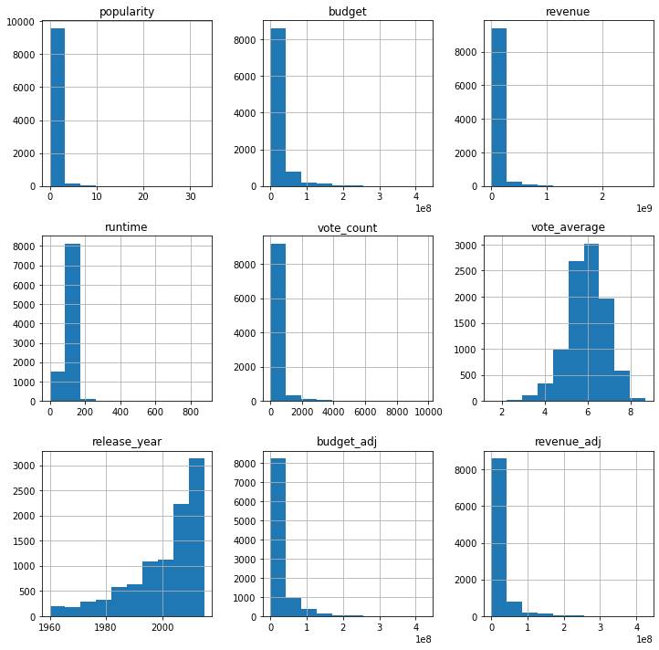

```python
movies.hist(figsize=(12,12));
```

Apart from vote_average and release_year, rest of the variables have postively skewed disributions.

## Exploratory Data Analysis

### What kinds of properties are associated with movies that have high revenues?

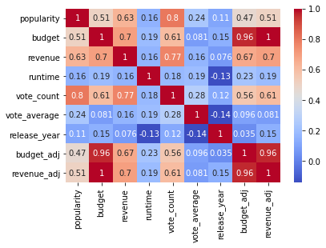

```python
# exploring the relationship between variables
corrMatrix = movies.corr()
sn.heatmap(corrMatrix, annot=True, cmap="coolwarm");
```

From the correlation matrix, I gather that the variables budget, popularity and vote count may affect the revenue of the movies. From this correlation lets find out if the votecount affects revenue.

### How does vote count affect revenue ?

```python
# Function to convert the value in millions

def millions(x, pos):
    'The two args are the value and tick position'
    return '%1.1fM' % (x * 1e-6)

formatter = FuncFormatter(millions)
```

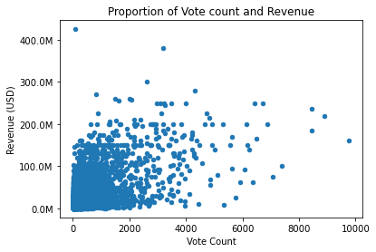

```python
# Plotting to understand the distribution between vote count and revenue

ax = movies.plot(x='vote_count', y='revenue_adj', kind='scatter');
plt.ylabel('Revenue (USD)')
plt.xlabel('Vote Count')
plt.title('Proportion of Vote count and Revenue');
ax.yaxis.set_major_formatter(formatter)
```

```python
# Summary statictics of the vote_count and revenue_adj column
movies[['vote_count', 'revenue_adj']].describe()
```

|  | vote_count | revenue_adj |
| --- | --- | --- |
| count | 9772.000000 | 9.772000e+03 |
| mean | 239.312014 | 2.404598e+07 |
| std | 603.011504 | 2.912660e+07 |
| min | 10.000000 | 1.000000e+00 |
| 25% | 18.000000 | 1.617967e+07 |
| 50% | 46.000000 | 1.617967e+07 |
| 75% | 173.000000 | 1.928750e+07 |
| max | 9767.000000 | 4.250000e+08 |

```python
# Fetching records where vote_count greater than the vote_count mean

high_vote = movies.query('vote_count > vote_count.mean()')
high_vote.shape
```

```
(1966, 15)
```

```python
# Fetching records where vote_count lesser than the vote_count mean

low_vote = movies.query('vote_count <= vote_count.mean()')
low_vote.shape
```

```
(7806, 15)
```

```python
# Get the mean of all revenues grouped by high vote count

high_rev_mean = high_vote.groupby('vote_count').revenue_adj.mean().mean()
high_rev_mean
```

```
63442959.52804938
```

```python
# Get the mean of all revenues grouped by low vote count

low_rev_mean = low_vote.groupby('vote_count').revenue_adj.mean().mean()
low_rev_mean
```

```
22246990.951322626
```

```python
# determine the balance

balance = high_rev_mean- low_rev_mean
balance
```

```
41195968.57672675
```

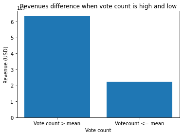

```python
# Plot the difference

plt.bar(["Vote count > mean", "Votecount <= mean"], [high_rev_mean,low_rev_mean])
plt.title("Revenues difference when vote count is high and low")
plt.xlabel("Vote count")
plt.ylabel("Revenue (USD)");
```

### Which genre has most number of movies?

```python
# Viewing the genres column
movies.genres.head(5)
```

```
0    Action|Adventure|Science Fiction|Thriller
1    Action|Adventure|Science Fiction|Thriller
2           Adventure|Science Fiction|Thriller
3     Action|Adventure|Science Fiction|Fantasy
4                        Action|Crime|Thriller
Name: genres, dtype: object
```

Since the genres column contains multiple genres seperated by a "|". I want to seperate the multiple genres and find the count for each genre.

```python
# convert all the genres to a string seperated by '|'
genres_str = movies['genres'].str.cat(sep='|')

# convert it to a series and find the count of distinct genres
genres_count = pd.Series(genres_str.split('|')).value_counts()

genres_count
```

```
Drama              4364
Comedy             3433
Thriller           2746
Action             2235
Romance            1570
Horror             1526
Adventure          1384
Crime              1299
Science Fiction    1136
Family             1095
Fantasy             840
Mystery             773
Animation           617
Music               339
Documentary         317
History             306
War                 258
Western             160
TV Movie            132
Foreign             120
dtype: int64
```

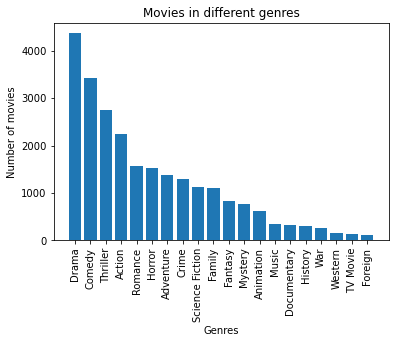

```python
plt.bar(genres_count.index, genres_count)
plt.title('Movies in different genres')
plt.xlabel('Genres')
plt.ylabel('Number of movies');
plt.xticks(rotation=90);
```

Most movies are produced in the genre 'Drama' followed by comedy, thriller, action and romance.

### Which genres generate the highest revenue?

```python
# Split the multiple genres and assign them to new rows
split_genres = movies.assign(genres = movies['genres'].str.split('|')).explode('genres')
split_genres.head(5)
```

|  | popularity | budget | revenue | original_title | cast | director | runtime | genres | production_companies | release_date | vote_count | vote_average | release_year | budget_adj | revenue_adj |
| --- | --- | --- | --- | --- | --- | --- | --- | --- | --- | --- | --- | --- | --- | --- | --- |
| 0 | 32.985763 | 150000000 | 1513528810 | Jurassic World | Chris Pratt\|Bryce Dallas Howard\|Irrfan Khan\|Vi... | Colin Trevorrow | 124 | Action | Universal Studios\|Amblin Entertainment\|Legenda... | 2015-06-09 | 5562 | 6.5 | 2015 | 137999939 | 150000000 |
| 0 | 32.985763 | 150000000 | 1513528810 | Jurassic World | Chris Pratt\|Bryce Dallas Howard\|Irrfan Khan\|Vi... | Colin Trevorrow | 124 | Adventure | Universal Studios\|Amblin Entertainment\|Legenda... | 2015-06-09 | 5562 | 6.5 | 2015 | 137999939 | 150000000 |
| 0 | 32.985763 | 150000000 | 1513528810 | Jurassic World | Chris Pratt\|Bryce Dallas Howard\|Irrfan Khan\|Vi... | Colin Trevorrow | 124 | Science Fiction | Universal Studios\|Amblin Entertainment\|Legenda... | 2015-06-09 | 5562 | 6.5 | 2015 | 137999939 | 150000000 |
| 0 | 32.985763 | 150000000 | 1513528810 | Jurassic World | Chris Pratt\|Bryce Dallas Howard\|Irrfan Khan\|Vi... | Colin Trevorrow | 124 | Thriller | Universal Studios\|Amblin Entertainment\|Legenda... | 2015-06-09 | 5562 | 6.5 | 2015 | 137999939 | 150000000 |
| 1 | 28.419936 | 150000000 | 378436354 | Mad Max: Fury Road | Tom Hardy\|Charlize Theron\|Hugh Keays-Byrne\|Nic... | George Miller | 120 | Action | Village Roadshow Pictures\|Kennedy Miller Produ... | 2015-05-13 | 6185 | 7.1 | 2015 | 137999939 | 150000000 |

```python
# The shapes of the dataframes before and after the split of genres column
movies.shape, split_genres.shape
```

```
((9772, 15), (24650, 15))
```

```python
# Group genres with revenue_adjusted
df = split_genres.groupby("genres").revenue_adj.mean()
df
```

```
genres
Action             3.558653e+07
Adventure          4.556482e+07
Animation          3.566495e+07
Comedy             2.282625e+07
Crime              2.440969e+07
Documentary        1.482992e+07
Drama              2.068793e+07
Family             3.479611e+07
Fantasy            4.213959e+07
Foreign            1.452879e+07
History            2.684533e+07
Horror             1.498648e+07
Music              1.980537e+07
Mystery            2.386165e+07
Romance            2.109597e+07
Science Fiction    3.336913e+07
TV Movie           1.541514e+07
Thriller           2.484159e+07
War                2.829176e+07
Western            2.826362e+07
Name: revenue_adj, dtype: float64
```

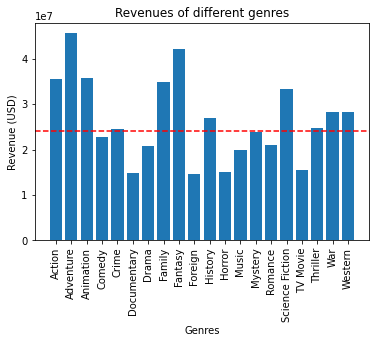

```python
plt.bar(df.index, df)
plt.title('Revenues of different genres')
plt.axhline(movies.revenue_adj.mean(), color='r', linestyle='--');
plt.xlabel('Genres')
plt.ylabel('Revenue (USD)');
plt.xticks(rotation=90);
```

## Conclusions

### Limitation:

- Considering the vote count to be higher if it is greater than the mean.